# TP Estadística 2

Diego Gornati

# Ejercicio 1

El Departamento de nutrición de la Ciudad desea analizar los efectos del tipo de harina y del porcentaje de endulzamiento sobre los atributos físicos de un determinado tipo de torta, a la venta actualmente. Para ello, se diseñó un experimento utilizando dos tipos de harina (multipropósito y harina para tortas), y distintos porcentajes de endulzamiento, en cuatro niveles diferentes. Los siguientes datos corresponden a la información de la densidad específica de muestras de tortas preparadas con las distintas combinaciones posibles. Se prepararon 3 tortas con cada una de las combinaciones posibles.

```r
azucar <- as.factor(c(0, 0, 0, 50, 50, 50, 75, 75, 75, 100, 100, 100,
                      0, 0, 0, 50, 50, 50, 75, 75, 75, 100, 100, 100))
densidad <- c(0.90, 0.87, 0.90, 0.86, 0.89, 0.91, 0.93, 0.88, 0.87, 0.79, 0.82, 0.80,
              0.91, 0.90, 0.80, 0.88, 0.82, 0.83, 0.86, 0.85, 0.80, 0.86, 0.85, 0.85)
harina <- as.factor(c("general", "general", "general", "general", "general", "general",
            "general", "general", "general", "general", "general", "general",
            "tortas", "tortas", "tortas", "tortas", "tortas", "tortas",
            "tortas", "tortas", "tortas", "tortas", "tortas", "tortas"))
df1 <- data.frame(azucar, harina, densidad)
df1
```

```
##    azucar  harina densidad
## 1       0 general     0.90
## 2       0 general     0.87
## 3       0 general     0.90
## 4      50 general     0.86
## 5      50 general     0.89
## 6      50 general     0.91
## 7      75 general     0.93
## 8      75 general     0.88
## 9      75 general     0.87
## 10    100 general     0.79
## 11    100 general     0.82
## 12    100 general     0.80
## 13      0  tortas     0.91
## 14      0  tortas     0.90
## 15      0  tortas     0.80
## 16     50  tortas     0.88
## 17     50  tortas     0.82
## 18     50  tortas     0.83
## 19     75  tortas     0.86
## 20     75  tortas     0.85
## 21     75  tortas     0.80
## 22    100  tortas     0.86
## 23    100  tortas     0.85
## 24    100  tortas     0.85
```

## Preguntas

**1) Existen diferencias estadísticamente significativas debidas al tipo de harina utilizada?**

**2) Existen diferencias estadísticamente significativas debidas al nivel de endulzamiento utilizado?**

**3) Existe interacción estadísticamente significativa entre los factores considerados?**

**4) Realizar los gráficos de medias e interpretar.**

## Análisis de Varianza

Realizamos este análisis para determinar si hay diferencia estadísticamente significativa entre las medias de las variables en estudio.

### Requisitos para anova

Realizo un testeo de la normalidad de las variables, comprobando que ellas tengan una distribución aproximadamente normal, mediante un test de Shapiro:

```r
shap1 <- df1 %>%
  group_by(azucar, harina) %>%
  shapiro_test(densidad)
shap1
```

```
## # A tibble: 8 x 5
##   azucar harina  variable statistic     p
##   <fct>  <fct>   <chr>        <dbl> <dbl>
## 1 0      general densidad     0.75  0
## 2 0      tortas  densidad     0.818 0.157
## 3 50     general densidad     0.987 0.780
## 4 50     tortas  densidad     0.871 0.298
## 5 75     general densidad     0.871 0.298
## 6 75     tortas  densidad     0.871 0.298
## 7 100    general densidad     0.964 0.637
## 8 100    tortas  densidad     0.75  0
```

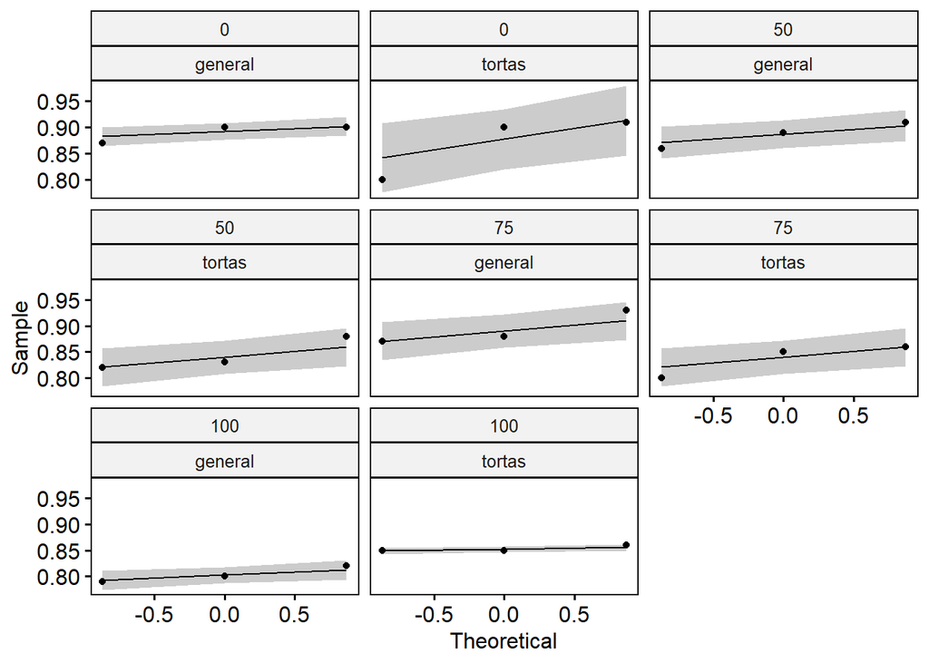

```r
ggqqplot(df1, "densidad", facet.by = "azucar*harina")
```

Realizo un test de la homoscedasticidad de las variables, comprobando que tengan una varianza aproximadamente igual:

```r
df1 %>% levene_test(densidad ~ azucar*harina)
```

```
## # A tibble: 1 x 4
##     df1   df2 statistic     p
##   <int> <int>     <dbl> <dbl>
## 1     7    16     0.413 0.880
```

Resúmenes estadísticos

```r
df1 %>%
  group_by(azucar,harina) %>%
  get_summary_stats(densidad, type = "mean_sd")
```

```
## # A tibble: 8 x 6
##   azucar harina  variable     n  mean    sd
##   <fct>  <fct>   <chr>    <dbl> <dbl> <dbl>
## 1 0      general densidad     3 0.89  0.017
## 2 0      tortas  densidad     3 0.87  0.061
## 3 50     general densidad     3 0.887 0.025
## 4 50     tortas  densidad     3 0.843 0.032
## 5 75     general densidad     3 0.893 0.032
## 6 75     tortas  densidad     3 0.837 0.032
## 7 100    general densidad     3 0.803 0.015
## 8 100    tortas  densidad     3 0.853 0.006
```

### ANOVA

```r
adf <- aov(densidad ~ azucar+harina, data = df1)
summary(adf)
```

```
##             Df   Sum Sq  Mean Sq F value Pr(>F)
## azucar       3 0.008713 0.002904   2.110  0.133
## harina       1 0.001838 0.001837   1.335  0.262
## Residuals   19 0.026146 0.001376
```

### ANOVA de dos factores

```r
adf_interac <- aov(densidad ~ azucar*harina, data = df1)
summary(adf_interac)
```

```
##               Df   Sum Sq  Mean Sq F value Pr(>F)
## azucar         3 0.008713 0.002904   2.904 0.0670 .
## harina         1 0.001838 0.001838   1.838 0.1941
## azucar:harina  3 0.010146 0.003382   3.382 0.0442 *
## Residuals     16 0.016000 0.001000
## ---
## Signif. codes:  0 '***' 0.001 '**' 0.01 '*' 0.05 '.' 0.1 ' ' 1
```

## Conclusiones del análisis de la varianza

En tal sentido, se puede dar respuesta a las preguntas **1** y **2**, afirmando que *no hay diferencia estadísticamente significativa* en la densidad obtenida teniendo en cuenta los factores de cantidad de azucar y tipo de harina por separado.

Por otro lado, dando respuesta a la **pregunta 3**, se puede afirmar que *hay diferencia estadísticamente significativa* en la densidad obtenida teniendo en cuenta los factores de cantidad de azucar y tipo de harina en interacción (siendo el p de 0.0442).

Por último, para obordar lo indagado en la **pregunta 4** se visualiza la interacción entre las variables.

## Gráfico de medias

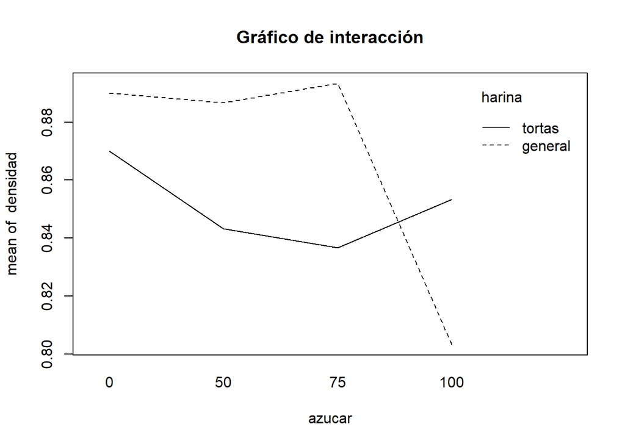

```r
with(df1, interaction.plot(azucar, harina, densidad, fun = mean,
                           main = "Gráfico de interacción"))
```

A partir de lo visualizado en el gráfico previo se puede afirmar que existe interacción entre las variables, ya que la proyección de las mismas dista mucho de ser paralela. En tal sentido, se puede apreciar que mientras la harina general mantiene su densidad aproximadamente constante y disminuye abruptamente a partir de una concentración de azucar de .75, para el caso de la harina para tortas su densidad disminuye a medida que aumenta la concentración de azucar para cambiar su tendencia y aumentar la densidad a partir del .75 de concentración de azúcar en adelante.

# Ejercicio 2

**Tasa de homicidios en Detroit**

En un estudio que investiga el papel de las armas de fuego en el aumento de la tasa de homicidios de Detroit, se recogieron datos para los años 1961-1973. La variable de respuesta (la tasa de homicidios) y las variables potencialmente predictoras del comportamiento de ésta, se describen a continuación (archivo p301.sav):

Se requiere construir una ecuación de regresión que relacione la Tasa de Homicidios (variable H), con el resto de las variables disponibles, y determinar si estas variables son útiles para predecir la Tasa de Homicidios.

## Preguntas

1. Cuál es el nivel de asociación lineal de las variables predictoras con la variable H? Comentar.
2. Realizar una regresión lineal múltiple, seleccionando los mejores predictores entre las variables independientes disponibles, utilizando un método de selección automática. Describir el proceso de selección automática utilizado. (Sug. Considerar como probabilidad de entrada 0.10 y de salida del modelo 0.15.)
3. Qué información da el coeficiente de determinación?
4. Cuáles son los supuestos necesarios para definir la prueba inferencial de los estimadores de los parámeros?
5. Analizar la bondad del ajuste del modelo obtenido, comentando los indicadores y/o test que considera.
6. Realizar un análisis de los residuos del modelo para evaluar el cumplimiento de los supuestos. Para esto, realizar gráficos de los residuos con el valor predicho.
7. Analizar la colinealidad de las variables predictoras presentes en la ecuación.
8. Analizar la presencia de observaciones atípicas y/o influyentes. Comentar y resolver según el caso.

```r
detroit <-read_sav("p301.sav")
detroit$YEAR = NULL
head(detroit)
```

```
## # A tibble: 6 x 12
##     FTP UNEMP     M   LIC    GR CLEAR      W  NMAN     G    HE    WE     H
##   <dbl> <dbl> <dbl> <dbl> <dbl> <dbl>  <dbl> <dbl> <dbl> <dbl> <dbl> <dbl>
## 1  260. 11     456.  178.  216.  93.4 558724  538.  134.  2.98  117.  8.60
## 2  270.  7     480.  156.  180.  88.5 538584  548.  138.  3.09  134.  8.90
## 3  272.  5.20  506.  198.  210.  94.4 519171  563.  144.  3.23  142.  8.52
## 4  273.  4.30  536.  222.  232.  92   500457  591   150.  3.33  148.  8.89
## 5  273.  3.5   576   302.  298.  91   482418  626.  164.  3.46  160. 13.1
## 6  261.  3.20  602.  391.  368.  87.4 465029  660.  180.  3.60  157. 14.6
```

## Asociación lineal

### Valores

```r
cor(x = detroit, method = "pearson")
```

```
##              FTP        UNEMP          M        LIC          GR      CLEAR
## FTP    1.0000000  0.292549420  0.4182908  0.5685212  0.70236680 -0.9742599
## UNEMP  0.2925494  1.000000000 -0.6517190 -0.1671449 -0.03287467 -0.3056631
## M      0.4182908 -0.651718959  1.0000000  0.6983145  0.62778120 -0.4292949
## LIC    0.5685212 -0.167144946  0.6983145  1.0000000  0.90379302 -0.5548320
## GR     0.7023668 -0.032874670  0.6277812  0.9037930  1.00000000 -0.6831611
## CLEAR -0.9742599 -0.305663099 -0.4292949 -0.5548320 -0.68316112  1.0000000
## W     -0.8799107  0.090013214 -0.7652255 -0.7815460 -0.84782368  0.8821079
## NMAN   0.8818185 -0.038947279  0.7503422  0.7848606  0.84329238 -0.8915961
## G      0.8793086  0.007512467  0.7097715  0.8037000  0.86242889 -0.8934356
## HE     0.9365055  0.230809707  0.4536647  0.4216629  0.57352189 -0.9574269
## WE     0.9222516  0.131281687  0.5023350  0.3910047  0.55589549 -0.9362843
## H      0.9640610  0.210141728  0.5464227  0.7262896  0.81628728 -0.9684603
##                 W        NMAN            G         HE         WE          H
## FTP   -0.87991074  0.88181847  0.879308571  0.9365055  0.9222516  0.9640610
## UNEMP  0.09001321 -0.03894728  0.007512467  0.2308097  0.1312817  0.2101417
## M     -0.76522553  0.75034215  0.709771506  0.4536647  0.5023350  0.5464227
## LIC   -0.78154603  0.78486061  0.803700034  0.4216629  0.3910047  0.7262896
## GR    -0.84782368  0.84329238  0.862428887  0.5735219  0.5558955  0.8162873
## CLEAR  0.88210786 -0.89159606 -0.893435576 -0.9574269 -0.9362843 -0.9684603
## W      1.00000000 -0.99537633 -0.985670491 -0.8622352 -0.8585848 -0.9469213
## NMAN  -0.99537633  1.00000000  0.990035941  0.8695054  0.8555694  0.9559347
## G     -0.98567049  0.99003594  1.000000000  0.8572888  0.8264266  0.9580545
## HE    -0.86223522  0.86950540  0.857288766  1.0000000  0.9827635  0.9134063
## WE    -0.85858484  0.85556944  0.826426612  0.9827635  1.0000000  0.8881526
## H     -0.94692129  0.95593473  0.958054543  0.9134063  0.8881526  1.0000000
```

### Gráfico

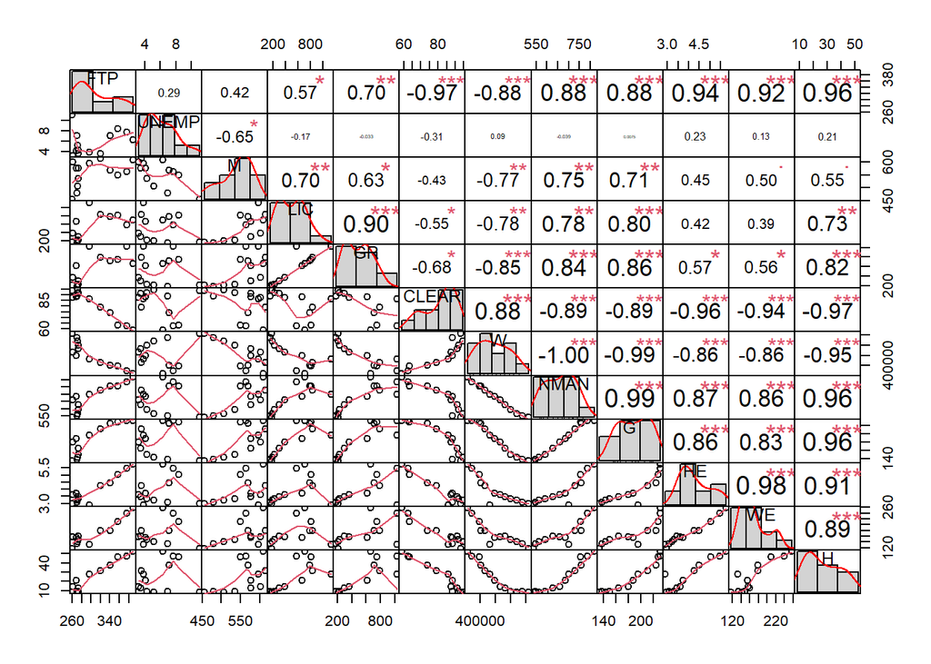

```r
chart.Correlation(detroit, histogram = TRUE, pch = 19)
```

### Conclusiones del análisis de correlación

Mientras que las que presentan una correlación más baja son:

- UNEMP, “Porcentaje de desempleados” (0.2101417) y
- M, “Cantidad de trabajadores en la industria manufacturera (en miles)” (0.5464227).

## Regresión lineal múltiple

```r
modelo <- lm(H ~ FTP+UNEMP+M+LIC+GR+CLEAR+W+NMAN+G+HE+WE, data = detroit)
ols_step_best_subset(modelo, pent = 0.10, prem = 0.15)
```

```
##                Best Subsets Regression
## ------------------------------------------------------
## Model Index    Predictors
## ------------------------------------------------------
##      1         CLEAR
##      2         LIC CLEAR
##      3         UNEMP LIC WE
##      4         UNEMP LIC CLEAR WE
##      5         UNEMP LIC CLEAR W WE
##      6         FTP UNEMP LIC CLEAR W WE
##      7         FTP UNEMP M LIC CLEAR NMAN WE
##      8         FTP M LIC W NMAN G HE WE
##      9         FTP M LIC GR W NMAN G HE WE
##     10         FTP UNEMP M LIC GR W NMAN G HE WE
##     11         FTP UNEMP M LIC GR CLEAR W NMAN G HE WE
## ------------------------------------------------------
##
##                                                     Subsets Regression Summary
## -----------------------------------------------------------------------------------------------------------------------------------
##                        Adj.        Pred
## Model    R-Square    R-Square    R-Square      C(p)         AIC        SBIC        SBC        MSEP        FPE       HSP       APC
## -----------------------------------------------------------------------------------------------------------------------------------
##   1        0.9379      0.9323      0.9225    1215.0959    78.4277     35.6200    80.1226    236.9508    20.9815    1.8184    0.0847
##   2        0.9895      0.9874      0.9831     200.0290    57.3254     13.0531    59.5852     44.5278     4.1636    0.3759    0.0168
##   3        0.9979      0.9972      0.9932      36.4845    38.4274     -4.9009    41.2522     10.0378     0.9850    0.0941    0.0040
##   4        0.9988      0.9982      0.9956      20.2396    32.8944     -8.7924    36.2841      6.4265     0.6573    0.0678    0.0027
##   5        0.9992      0.9987      0.9956      14.1857    29.3629     -9.2981    33.3175      4.8992     0.5181    0.0591    0.0021
##   6        0.9996      0.9992      0.9977       8.9609    22.9673     -5.8647    27.4869      3.0820     0.3336    0.0434    0.0013
##   7        0.9997      0.9992      0.9878       9.4880    22.3077     -0.5404    27.3923      3.1398     0.3425    0.0530    0.0014
##   8        0.9997      0.9992      0.9894      10.4824    22.1184      6.1473    27.7679      3.5375     0.3790    0.0747    0.0015
##   9        0.9999      0.9995      0.9718       9.4892    13.8536     25.7526    20.0681      2.4092     0.2399    0.0678    0.0010
##  10        0.9999      0.9995      0.6715      10.5979    10.0914     28.3491    16.8708      3.0931     0.2410    0.1306    0.0010
##  11        0.9999      0.9994     -0.6458      12.0000     5.9983    -30.8941    13.3426         Inf     0.3142       Inf    0.0013
## -----------------------------------------------------------------------------------------------------------------------------------
## AIC: Akaike Information Criteria
##  SBIC: Sawa's Bayesian Information Criteria
##  SBC: Schwarz Bayesian Criteria
##  MSEP: Estimated error of prediction, assuming multivariate normality
##  FPE: Final Prediction Error
##  HSP: Hocking's Sp
##  APC: Amemiya Prediction Criteria
```

### Conclusiones del análisis de regresión lineal múltiple

Dando respuesta a la **Pregunta 2** se puede observar que el modelo con una única variable predictora (CLEAR) explica un %93.23 de la variabilidad de la variable H, y si bien los modelos que incorporan más variables aumentan dicho porcentaje (a %98.74 con dos, a %99.72 con tres, etc.) por principio de parcimonia y el criterio de comparación de R-cuadrado ajustados se decide conservar el modelo con una única predictora en un alto porcentaje.

En cuanto a la **Pregunta 3**, El coeficiente de determinación es la proporción de la varianza total de la variable explicada por la regresión, y en este caso para el modelo elegido esta varianza es del %93.79.

Respondiendo a la **Pregunta 4**, los supuestos necesarios para definir la prueba inferencial de los estimadores de los parámeros son:

- La relación debe ser lineal
- La varianza de los residuos debe ser constante (homocedasticidad)
- Debe ser una muestra independiente
- Debe haber una distribución normal de los errores

### Regresión del modelo elegido

```r
modelo1 <- lm (H ~ CLEAR, data=detroit)
as_flextable(modelo1)
```

|  | Estimate | Standard Error | t value | Pr(>\|t\|) |  |
| --- | --- | --- | --- | --- | --- |
| (Intercept) | 127.222 | 8.008 | 15.887 | 0.0000 | *** |
| CLEAR | -1.254 | 0.097 | -12.891 | 0.0000 | *** |

Respecto a lo indagado en la **Pregunta 5**, se obtiene que el modelo elegido presenta una capacidad predictiva significativa con un F value de 166.2 en 1 a 11 grados de libertad, y un p-value de 5.553e-08

### Análisis de los residuos

#### Residuales

```r
residuals(modelo1)
```

```
##           1           2           3           4           5           6
## -1.54248953 -7.38475957 -0.36896550 -3.00742502 -0.08094962 -3.09363393
##           7           8           9          10          11          12
##  4.82454045  8.73678210  3.29676304  2.80379241 -1.48821015 -1.63638026
##          13
## -1.05906442
## attr(,"label")
## [1] "H"
## attr(,"format.spss")
## [1] "F9.2"
## attr(,"display_width")
## [1] 9
```

#### Grafico

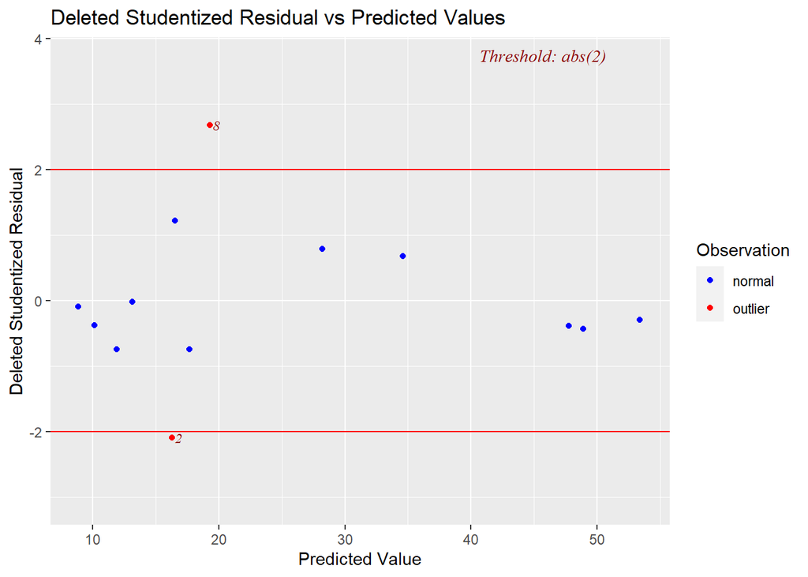

```r
ols_plot_resid_stud_fit(modelo1)
```

**Pregunta 6**: Del análisis de los datos precedentes se puede observar que se obtienen dos outliers el caso 2 (-7.38475957) y el caso 8 (8.73678210).

**Pregunta 7**: Se tiene una sola variable predictora en el modelo elegido, por lo tanto no se puede testear multicolinealidad.

### observaciones atípicas y/o influyentes

Para analizar lo solicitado en el **Punto 8** se realizará un gráfico de la Distancia de Cook para cada uno de los casos, considerando que un valor de C mayor a 1 es considerado grande.

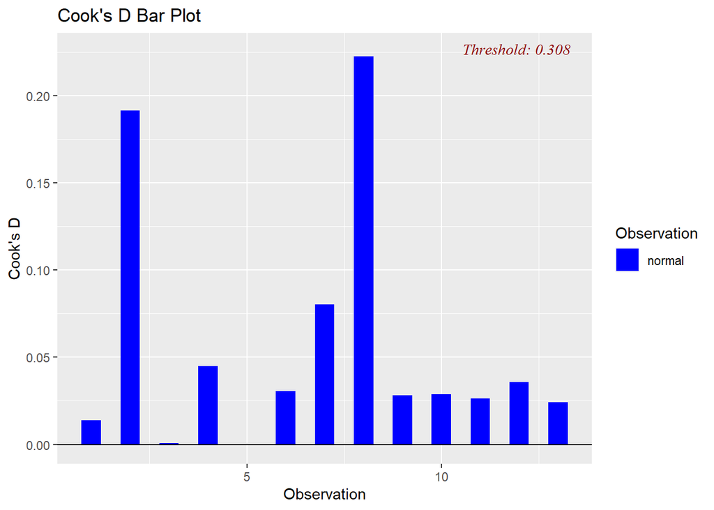

```r
ols_plot_cooksd_bar(modelo1, print_plot = TRUE)
```

En base al análisis del gráfico previo, y prestando especial atención a los casos 2 y 8 que son los outliers detectados previamente, se concluye que estos últimos no se presentan como valores atípicos o influyentes.

# Ejercicio 3

## Factores de riesgo de bajo peso al nacer

El bajo peso al nacer, definido como por un peso al nacer inferior a 2500 gr., ha sido una preocupación de los médicos durante años debido a que tanto las tasas de mortalidad como la de nacimientos defectuosos son muy altas para los niños con bajo peso al nacer. El comportamiento de la mujer durante el embarazo (incluyendo la dieta, los hábitos tabáquicos y los cuidados prenatales) pueden alterar las chances de un parto de un niño con bajo peso. Los datos que se presentan en este ejercicio corresponden a 189 nacimientos de los cuales 59 han resultado en niños con bajo peso. El objetivo de este ejercicio es determinar cuáles de las variables presentes en la base de datos que se adjunta son factores de riesgo de bajo peso al nacer.

La base de datos que se presenta (archivo LOWBWT.sav) contiene las siguientes variables:

- ID: Código de identificación
- LOW: Bajo peso al nacer. (0 = ≥2500 g; 1 = <2500 g) (variable dependiente)
- AGE: Edad de la madre
- LWT: Peso de la madre el momento de la última menstruación (en libras)
- RACE: Raza (1 = White; 2 = Black; 3 = Other)
- SMOKE: Fumó durante el embarazo (0 = No 1 = Yes)
- PTL: Antecedentes de embarazos prematuros (0 = None; 1 = One; 2 = Two, etc).
- HT: Antecedentes de hipertensión arterial (0 = No; 1 = Yes)
- UI: Irritabilidad uterine (0 = No; 1 = Yes)
- FTV: Cantidad de consultas obstétricas durante el primer trimestre (0 = None; 1 = One; 2 = Two, etc.)
- BWT: Peso al nacer del bebé en gramos

Se requiere construir una ecuación de regresión logística que relacione la variable dicotómica que indica si se trata de un nacimiento con bajo peso al nacer con el resto de las variables que corresponda, y determinar si estas variables son útiles para predecir la variable dependiente.

## Preguntas

1. Calcular el riesgo relativo y los odds ratio de la variable dependiente con todas las variables dicotómicas. Analizar los resultados.
2. Cuál es la definición de odds ratio? Qué información suministra y de qué manera puede calcularse utilizando la regresión logística?
3. Calcule los odds ratio de cada una de las variables predictoras con la variable dependiente? Comentar.
4. Realizar una regresión logística múltiple, seleccionando los mejores predictores entre las variables independientes disponibles, utilizando un método de selección automática.
5. Según el modelo obtenido, cuáles son los principales factores de riesgo del bajo peso y cuál es la magnitud de su efecto?
6. Cuáles son los supuestos necesarios para definir la prueba inferencial de los estimadores de los parámetros?
7. Analizar la bondad del ajuste del modelo obtenido, comentando los indicadores y/o test que considera.
8. Indicar porcentaje de casos bien predichos por el modelo.

```r
LOWBWT <-read_sav("LOWBWT.sav")
head (LOWBWT)
```

```
## # A tibble: 6 x 11
##      ID       LOW   AGE   LWT       RACE   SMOKE   PTL     HT     UI   FTV   BWT
##   <dbl> <dbl+lbl> <dbl> <dbl>  <dbl+lbl> <dbl+l> <dbl> <dbl+> <dbl+> <dbl> <dbl>
## 1     4    1 [Si]    28   120 3 [Otra]    1 [Si]     1 0 [No] 1 [Si]     0   709
## 2    10    1 [Si]    29   130 1 [Blanca]  0 [No]     0 0 [No] 1 [Si]     2  1021
## 3    11    1 [Si]    34   187 2 [Negra]   1 [Si]     0 1 [Si] 0 [No]     0  1135
## 4    13    1 [Si]    25   105 3 [Otra]    0 [No]     1 1 [Si] 0 [No]     0  1330
## 5    15    1 [Si]    25    85 3 [Otra]    0 [No]     0 0 [No] 1 [Si]     0  1474
## 6    16    1 [Si]    27   150 3 [Otra]    0 [No]     0 0 [No] 0 [No]     0  1588
```

Para abordar la **Pregunta 1** se procederá a realizar el análisis de las varibles dicotómicas.

## Variables dicotómicas

### SMOKE

Se analiza la variable “Fumó durante el embarazo”:

```r
fumar <- glm(LOW~SMOKE,data=LOWBWT,family="binomial")
summary(fumar)
```

```
##
## Call:
## glm(formula = LOW ~ SMOKE, family = "binomial", data = LOWBWT)
##
## Deviance Residuals:
##     Min       1Q   Median       3Q      Max
## -1.0197  -0.7623  -0.7623   1.3438   1.6599
##
## Coefficients:
##             Estimate Std. Error z value Pr(>|z|)
## (Intercept)  -1.0871     0.2147  -5.062 4.14e-07 ***
## SMOKE         0.7041     0.3196   2.203   0.0276 *
## ---
## Signif. codes:  0 '***' 0.001 '**' 0.01 '*' 0.05 '.' 0.1 ' ' 1
##
## (Dispersion parameter for binomial family taken to be 1)
##
##     Null deviance: 234.67  on 188  degrees of freedom
## Residual deviance: 229.80  on 187  degrees of freedom
## AIC: 233.8
##
## Number of Fisher Scoring iterations: 4
```

```r
coefficients((fumar))
```

```
## (Intercept)       SMOKE
##  -1.0870515   0.7040592
```

```r
or_glm(data = LOWBWT, model = fumar, incr = list(SMOKE=1))
```

```
##   predictor oddsratio ci_low (2.5) ci_high (97.5) increment
## 1     SMOKE     2.022        1.082          3.801         1
```

**Conclusión**

- Riesgo relativo: Es una realción significativa, ya que posee un valor de p menor a 0.05 (0.0276).
- Odds ratio: Se poseen 2.022 más chances de tener un bebé con bajo peso al nacer si se fuma.

### HT

Se analiza la variable “Antecedentes de hipertensión arterial”:

```r
hiper <- glm(LOW~HT,data=LOWBWT,family="binomial")
summary(hiper)
```

```
##
## Call:
## glm(formula = LOW ~ HT, family = "binomial", data = LOWBWT)
##
## Deviance Residuals:
##     Min       1Q   Median       3Q      Max
## -1.3232  -0.8341  -0.8341   1.5652   1.5652
##
## Coefficients:
##             Estimate Std. Error z value Pr(>|z|)
## (Intercept)  -0.8771     0.1650  -5.315 1.07e-07 ***
## HT            1.2135     0.6083   1.995   0.0461 *
## ---
## Signif. codes:  0 '***' 0.001 '**' 0.01 '*' 0.05 '.' 0.1 ' ' 1
##
## (Dispersion parameter for binomial family taken to be 1)
##
##     Null deviance: 234.67  on 188  degrees of freedom
## Residual deviance: 230.65  on 187  degrees of freedom
## AIC: 234.65
##
## Number of Fisher Scoring iterations: 4
```

```r
coefficients((hiper))
```

```
## (Intercept)          HT
##   -0.877070    1.213542
```

```r
or_glm(data = LOWBWT, model = hiper, incr = list(HT=1))
```

```
##   predictor oddsratio ci_low (2.5) ci_high (97.5) increment
## 1        HT     3.365        1.028         11.829         1
```

**Conclusión**

- Riesgo relativo: Es una realción significativa, ya que posee un valor de p menor a 0.05 (0.0461).
- Odds ratio: Se poseen 3.365 más chances de tener un bebé con bajo peso al nacer si se tiene antecedentes de hipertensión arterial.

### UI

Se analiza la variable “Irritabilidad uterina”:

```r
irrit <- glm(LOW~UI,data=LOWBWT,family="binomial")
summary(irrit)
```

```
##
## Call:
## glm(formula = LOW ~ UI, family = "binomial", data = LOWBWT)
##
## Deviance Residuals:
##     Min       1Q   Median       3Q      Max
## -1.1774  -0.8097  -0.8097   1.1774   1.5967
##
## Coefficients:
##             Estimate Std. Error z value Pr(>|z|)
## (Intercept)  -0.9469     0.1756  -5.392 6.97e-08 ***
## UI            0.9469     0.4168   2.272   0.0231 *
## ---
## Signif. codes:  0 '***' 0.001 '**' 0.01 '*' 0.05 '.' 0.1 ' ' 1
##
## (Dispersion parameter for binomial family taken to be 1)
##
##     Null deviance: 234.67  on 188  degrees of freedom
## Residual deviance: 229.60  on 187  degrees of freedom
## AIC: 233.6
##
## Number of Fisher Scoring iterations: 4
```

```r
coefficients((irrit))
```

```
## (Intercept)          UI
##  -0.9469277   0.9469277
```

```r
or_glm(data = LOWBWT, model = irrit, incr = list(UI=1))
```

```
##   predictor oddsratio ci_low (2.5) ci_high (97.5) increment
## 1        UI     2.578        1.133          5.881         1
```

**Conclusión**

- Riesgo relativo: Es una realción significativa, ya que posee un valor de p menor a 0.05 (0.0231).
- Odds ratio: Se poseen 2.578 más chances de tener un bebé con bajo peso al nacer si se tiene irritabilidad uterina.

## Odds Ratio

Respondiendo a la **Pregunta 2** el momio (Odd) de un evento es la razón de la probabilidad que suceda el evento, a la probabilidad de que no suceda el evento. En estudios retrospectivos se utiliza la razon de momios (Odds Ratio) para estimar el riesgo relativo. La razón de momios (que es la razón de dos momios) no involucra las frecuencias marginales, por lo cual se puede medir dependencia aún cuando un estudio sea retrospectivo,donde el número de casos y el número de controles son fijados por el investigador y no se puede estimar el riesgo relativo.

A continuación se realizará el análisis de Odds ratio y riesgo relativo de las restantes variables explicativas, de manera de dar cumplimiento a la **Pregunta 3**.

## Variables predictoras

### AGE

Se analiza la variable “Edad de la madre”:

```r
AGE<-glm(LOW~AGE,data=LOWBWT,family="binomial")
summary(AGE)
```

```
##
## Call:
## glm(formula = LOW ~ AGE, family = "binomial", data = LOWBWT)
##
## Deviance Residuals:
##     Min       1Q   Median       3Q      Max
## -1.0402  -0.9018  -0.7754   1.4119   1.7800
##
## Coefficients:
##             Estimate Std. Error z value Pr(>|z|)
## (Intercept)  0.38458    0.73212   0.525    0.599
## AGE         -0.05115    0.03151  -1.623    0.105
##
## (Dispersion parameter for binomial family taken to be 1)
##
##     Null deviance: 234.67  on 188  degrees of freedom
## Residual deviance: 231.91  on 187  degrees of freedom
## AIC: 235.91
##
## Number of Fisher Scoring iterations: 4
```

```r
coefficients((AGE))
```

```
## (Intercept)         AGE
##  0.38458192 -0.05115294
```

```r
or_glm(data = LOWBWT, model = AGE, incr = list(AGE=5))
```

```
##   predictor oddsratio ci_low (2.5) ci_high (97.5) increment
## 1       AGE     0.774        0.562          1.046         5
```

**Conclusión**

- Riesgo relativo: No es una realción significativa, ya que en el supuesto de un aumento de 5 años en la edad de la madre se posee un valor de p mayor a 0.05 (0.105).

### LWT

Se analiza la variable “Peso de la madre el momento de la última menstruación”:

```r
LWT<-glm(LOW~LWT,data=LOWBWT,family="binomial")
summary(LWT)
```

```
##
## Call:
## glm(formula = LOW ~ LWT, family = "binomial", data = LOWBWT)
##
## Deviance Residuals:
##     Min       1Q   Median       3Q      Max
## -1.0951  -0.9022  -0.8018   1.3609   1.9821
##
## Coefficients:
##             Estimate Std. Error z value Pr(>|z|)
## (Intercept)  0.99831    0.78529   1.271   0.2036
## LWT         -0.01406    0.00617  -2.279   0.0227 *
## ---
## Signif. codes:  0 '***' 0.001 '**' 0.01 '*' 0.05 '.' 0.1 ' ' 1
##
## (Dispersion parameter for binomial family taken to be 1)
##
##     Null deviance: 234.67  on 188  degrees of freedom
## Residual deviance: 228.69  on 187  degrees of freedom
## AIC: 232.69
##
## Number of Fisher Scoring iterations: 4
```

```r
coefficients((LWT))
```

```
## (Intercept)         LWT
##  0.99831432 -0.01405826
```

```r
or_glm(data = LOWBWT, model = LWT, incr = list(LWT=1))
```

```
##   predictor oddsratio ci_low (2.5) ci_high (97.5) increment
## 1       LWT     0.986        0.973          0.997         1
```

**Conclusión**

- Riesgo relativo: Es una realción significativa, ya que posee un valor de p menor a 0.05 (0.0227).
- Odds ratio: Se poseen 0.014 menos chances de tener un bebé con bajo peso al nacer por cada unidad de aumento de peso de la madre el momento de la última menstruación (odds ratio de 0.986).

### RACE

Se analiza la variable “Raza” (1 = White; 2 = Black; 3 = Other):

```r
RACE<-glm(LOW~ factor(RACE),data=LOWBWT,family="binomial")
summary(RACE)
```

```
##
## Call:
## glm(formula = LOW ~ factor(RACE), family = "binomial", data = LOWBWT)
##
## Deviance Residuals:
##     Min       1Q   Median       3Q      Max
## -1.0489  -0.9665  -0.7401   1.4042   1.6905
##
## Coefficients:
##               Estimate Std. Error z value Pr(>|z|)
## (Intercept)    -1.1550     0.2391  -4.830 1.36e-06 ***
## factor(RACE)2   0.8448     0.4634   1.823   0.0683 .
## factor(RACE)3   0.6362     0.3478   1.829   0.0674 .
## ---
## Signif. codes:  0 '***' 0.001 '**' 0.01 '*' 0.05 '.' 0.1 ' ' 1
##
## (Dispersion parameter for binomial family taken to be 1)
##
##     Null deviance: 234.67  on 188  degrees of freedom
## Residual deviance: 229.66  on 186  degrees of freedom
## AIC: 235.66
##
## Number of Fisher Scoring iterations: 4
```

```r
coefficients((RACE))
```

```
##   (Intercept) factor(RACE)2 factor(RACE)3
##    -1.1549652     0.8448103     0.6361714
```

```r
or_glm(data = LOWBWT, model = RACE, incr = list(RACE=1))
```

```
##       predictor oddsratio ci_low (2.5) ci_high (97.5)          increment
## 1 factor(RACE)2     2.328        0.926          5.775 Indicator variable
## 2 factor(RACE)3     1.889        0.957          3.758 Indicator variable
```

**Conclusión**

- Riesgo relativo: No hay una realción significativa entre la “raza” de la madre y el bajo peso al nacer, ya que este supuesto posee un valor de p mayor a 0.05 (0.0683 para “raza” negra, y 0.0674 para otras etnias).

### PTL

Se analiza la variable “Antecedentes de embarazos prematuros” (0 = None; 1 = One; 2 = Two, etc):

```r
PTL<-glm(LOW~PTL,data=LOWBWT,family="binomial")
summary(PTL)
```

```
##
## Call:
## glm(formula = LOW ~ PTL, family = "binomial", data = LOWBWT)
##
## Deviance Residuals:
##     Min       1Q   Median       3Q      Max
## -1.8186  -0.8038  -0.8038   1.2471   1.6045
##
## Coefficients:
##             Estimate Std. Error z value Pr(>|z|)
## (Intercept)  -0.9642     0.1750  -5.511 3.57e-08 ***
## PTL           0.8018     0.3172   2.528   0.0115 *
## ---
## Signif. codes:  0 '***' 0.001 '**' 0.01 '*' 0.05 '.' 0.1 ' ' 1
##
## (Dispersion parameter for binomial family taken to be 1)
##
##     Null deviance: 234.67  on 188  degrees of freedom
## Residual deviance: 227.89  on 187  degrees of freedom
## AIC: 231.89
##
## Number of Fisher Scoring iterations: 4
```

```r
coefficients((PTL))
```

```
## (Intercept)         PTL
##  -0.9641890   0.8018058
```

```r
or_glm(data = LOWBWT, model = PTL, incr = list(PTL=1))
```

```
##   predictor oddsratio ci_low (2.5) ci_high (97.5) increment
## 1       PTL      2.23        1.218          4.284         1
```

**Conclusión**

- Riesgo relativo: Es una realción significativa, ya que posee un valor de p menor a 0.05 (0.0115).
- Odds ratio: Se poseen 2.23 más chances de tener un bebé con bajo peso al nacer si tiene antecedentes de embarazos prematuros

### FTV

Se analiza la variable “Cantidad de consultas obstétricas durante el primer trimestre” (0 = None; 1 = One; 2 = Two, etc.):

```r
FTV<-glm(LOW~FTV,data=LOWBWT,family="binomial")
summary(FTV)
```

```
##
## Call:
## glm(formula = LOW ~ FTV, family = "binomial", data = LOWBWT)
##
## Deviance Residuals:
##     Min       1Q   Median       3Q      Max
## -0.9029  -0.9029  -0.8537   1.4794   1.7229
##
## Coefficients:
##             Estimate Std. Error z value Pr(>|z|)
## (Intercept)  -0.6868     0.1948  -3.525 0.000423 ***
## FTV          -0.1351     0.1567  -0.862 0.388527
## ---
## Signif. codes:  0 '***' 0.001 '**' 0.01 '*' 0.05 '.' 0.1 ' ' 1
##
## (Dispersion parameter for binomial family taken to be 1)
##
##     Null deviance: 234.67  on 188  degrees of freedom
## Residual deviance: 233.90  on 187  degrees of freedom
## AIC: 237.9
##
## Number of Fisher Scoring iterations: 4
```

```r
coefficients((FTV))
```

```
## (Intercept)         FTV
##  -0.6867585  -0.1351199
```

```r
or_glm(data = LOWBWT, model = FTV, incr = list(FTV=1))
```

```
##   predictor oddsratio ci_low (2.5) ci_high (97.5) increment
## 1       FTV     0.874        0.632          1.174         1
```

**Conclusión**

- Riesgo relativo: La cantidad de consultas obstétricas durante el primer trimestre no tiene una realción significativa con el bajo peso al nacer, ya que posee un valor de p mayor a 0.05 (0.388527).

## Regresión logística múltiple

Siguiendo lo solicitado en la **Pregunta 4** a continuación se pasará a realizar una regresión logística múltiple, seleccionando los mejores predictores entre las variables independientes disponibles, utilizando un método de selección automática.

Para la selección automática se hará uso de la función stepAIC, que implementa la selección automática de variables pero en vez de utilizar los contrastes condicionales de razones de verosimilitudes, utiliza el criterio de información de Akaike. Este criterio penaliza los modelos con muchos parámetros frente a los modelos más parsimoniosos.

```r
log <- glm (LOW ~ 1, family = binomial, data=LOWBWT)
log1 <- stepAIC (log, scope = list(upper = ~ AGE + LWT+ factor(RACE) + SMOKE + PTL + HT + UI + FTV, lower =~1), direction = c("both"), trace=T,  pent = 0.10, prem = 0.15)
```

```
## Start:  AIC=236.67
## LOW ~ 1
##
##                Df Deviance    AIC
## + PTL           1   227.89 231.89
## + LWT           1   228.69 232.69
## + UI            1   229.60 233.60
## + SMOKE         1   229.81 233.81
## + HT            1   230.65 234.65
## + factor(RACE)  2   229.66 235.66
## + AGE           1   231.91 235.91
## <none>              234.67 236.67
## + FTV           1   233.90 237.90
##
## Step:  AIC=231.89
## LOW ~ PTL
##
##                Df Deviance    AIC
## + LWT           1   223.41 229.41
## + HT            1   223.58 229.58
## + AGE           1   224.27 230.27
## + factor(RACE)  2   222.53 230.53
## + SMOKE         1   224.78 230.78
## + UI            1   224.89 230.89
## <none>              227.89 231.89
## + FTV           1   227.30 233.30
## - PTL           1   234.67 236.67
##
## Step:  AIC=229.41
## LOW ~ PTL + LWT
##
##                Df Deviance    AIC
## + HT            1   215.96 223.96
## + factor(RACE)  2   217.68 227.68
## + SMOKE         1   220.54 228.54
## + AGE           1   221.05 229.05
## + UI            1   221.23 229.23
## <none>              223.41 229.41
## + FTV           1   223.12 231.12
## - LWT           1   227.89 231.89
```

[output cut: 42 more lines]

```
## - LWT           1   211.62 223.62
##
## Step:  AIC=217.99
## LOW ~ PTL + LWT + HT + factor(RACE) + SMOKE + UI
##
##                Df Deviance    AIC
## <none>              201.99 217.99
## - PTL           1   204.22 218.22
## - UI            1   204.90 218.90
## + AGE           1   201.43 219.43
## + FTV           1   201.93 219.93
## - SMOKE         1   207.73 221.73
## - LWT           1   208.11 222.11
## - factor(RACE)  2   210.31 222.31
## - HT            1   209.46 223.46
```

Habiéndose seleccionado las variables PTL + LWT + HT + factor(RACE) + SMOKE + UI, se procede a realizar una regresión logística con este modelo.

```r
log2 <- glm (LOW ~ PTL + LWT + HT + factor(RACE) + SMOKE + UI , family = binomial, data=LOWBWT)
summary (log2)
```

```
##
## Call:
## glm(formula = LOW ~ PTL + LWT + HT + factor(RACE) + SMOKE + UI,
##     family = binomial, data = LOWBWT)
##
## Deviance Residuals:
##     Min       1Q   Median       3Q      Max
## -1.9049  -0.8124  -0.5241   0.9483   2.1812
##
## Coefficients:
##                Estimate Std. Error z value Pr(>|z|)
## (Intercept)   -0.086550   0.951760  -0.091  0.92754
## PTL            0.503215   0.341231   1.475  0.14029
## LWT           -0.015905   0.006855  -2.320  0.02033 *
## HT             1.855042   0.695118   2.669  0.00762 **
## factor(RACE)2  1.325719   0.522243   2.539  0.01113 *
## factor(RACE)3  0.897078   0.433881   2.068  0.03868 *
## SMOKE          0.938727   0.398717   2.354  0.01855 *
## UI             0.785698   0.456441   1.721  0.08519 .
## ---
## Signif. codes:  0 '***' 0.001 '**' 0.01 '*' 0.05 '.' 0.1 ' ' 1
##
## (Dispersion parameter for binomial family taken to be 1)
##
##     Null deviance: 234.67  on 188  degrees of freedom
## Residual deviance: 201.99  on 181  degrees of freedom
## AIC: 217.99
##
## Number of Fisher Scoring iterations: 4
```

Del análisis de este modelo se desprende que las variables PTL y UI no son significativas, ya tienen un vaor de p mayor a 0.05 (0.14029 y 0.08519, respectivamente), por lo que se procederá a armar un nuevo modelo que no las incluya.

```r
log3 <- glm (LOW ~ LWT + HT + factor(RACE) + SMOKE , family = binomial, data=LOWBWT)
summary (log3)
```

```
##
## Call:
## glm(formula = LOW ~ LWT + HT + factor(RACE) + SMOKE, family = binomial,
##     data = LOWBWT)
##
## Deviance Residuals:
##     Min       1Q   Median       3Q      Max
## -1.7751  -0.8747  -0.5712   0.9634   2.1131
##
## Coefficients:
##                Estimate Std. Error z value Pr(>|z|)
## (Intercept)    0.352049   0.924438   0.381  0.70333
## LWT           -0.017907   0.006799  -2.634  0.00844 **
## HT             1.749163   0.690820   2.532  0.01134 *
## factor(RACE)2  1.287662   0.521648   2.468  0.01357 *
## factor(RACE)3  0.943645   0.423382   2.229  0.02583 *
## SMOKE          1.071566   0.387517   2.765  0.00569 **
## ---
## Signif. codes:  0 '***' 0.001 '**' 0.01 '*' 0.05 '.' 0.1 ' ' 1
##
## (Dispersion parameter for binomial family taken to be 1)
##
##     Null deviance: 234.67  on 188  degrees of freedom
## Residual deviance: 208.25  on 183  degrees of freedom
## AIC: 220.25
##
## Number of Fisher Scoring iterations: 4
```

El modelo resultante tiene un AIC ligeramente superior, pero todas las variables predictoras que incluye son significativas, siendo sus valores de p inferiores a 0.05 en todos los casos. Calculamos entonces los odds ratio para este modelo.

```r
or_glm(data = LOWBWT, model = log3, incr = list(RACE=1,SMOKE=1, HT=1, LWT=1))
```

```
##       predictor oddsratio ci_low (2.5) ci_high (97.5)          increment
## 1           LWT     0.982        0.968          0.995                  1
## 2            HT     5.750        1.540         24.408                  1
## 3 factor(RACE)2     3.624        1.307         10.284 Indicator variable
## 4 factor(RACE)3     2.569        1.136          6.030 Indicator variable
## 5         SMOKE     2.920        1.387          6.394                  1
```

Respondiendo a lo indagado en la **Pregunta 5**, a partir del análisis de este modelo se puede afirmar que los principales factores de riesgo del bajo peso son:

- LWT, el **peso de la madre el momento de la última menstruación** tiene una relación inversa con el riesgo de bajo peso, ya que se poseen 0.018 menos chances de tener un bebé con bajo peso al nacer por cada unidad de aumento de peso de la madre el momento de la última menstruación (odds ratio de 0.982).
- HT, los **antecedentes de hipertensión arterial** tienen el más alto efecto, ya que tiene 5.750 más chances de riesgo de bajo peso si presenta estos antecedentes.
- RACE, la **“raza”** (siendo 1 = White; 2 = Black; 3 = Other) también tienen un alto efecto, siendo que las madres de “raza” negra tienen 3.624 más chances de presentar esta problemática, y las madres de otra étnia presentan 2.569 más chances.
- SMOKE, si **fumó durante el embarazo** también tiene un alto efecto (aunque no tan marcado como las dos variables previas), aumentando las chances de riesgo de bajo peso en 2.920.

## Supuestos de la Regresión logística

Dando respuesta a la **Pregunta 6**, se entiende que los requisitos para una regresión logística son los siguientes:

- Respuesta binaria: La variable dependiente debe ser binaria.
- Independencia: las observaciones deben ser independientes.
- Multicolinealidad: se requiere de muy poca o nula multicolinealidad entre los predictores (para regresión logística múltiple).
- Linealidad: entre la variable independiente y el logaritmo natural de odds.
- Tamaño muestral: como regla general, se necesita como mínimo 10 casos con el resultado menos frecuente para cada variable independiente del modelo.

## Bondad del ajuste del modelo

```r
1 - pchisq(208.25, 183)
```

```
## [1] 0.09713175
```

Este valor de 1-Chi2 resulta mayor a 0.05, por lo cual no se desecha la hipótesis nula de que el modelo se ajusta globalmente bien a los datos.

## Porcentaje de casos bien predichos

Para dar respuesta a la **Pregunta 8** se determinan las probabilidades de corte del modelo.

```r
predic_final <- plogis(predict(log3, LOWBWT))
predic_final
```

```
##          1          2          3          4          5          6          7
## 0.55440172 0.12176672 0.75248528 0.76217962 0.44364928 0.19936117 0.39144473
##          8          9         10         11         12         13         14
## 0.34246473 0.66400404 0.55433303 0.38779876 0.44871042 0.31787347 0.26266549
##         15         16         17         18         19         20         21
## 0.44428507 0.22056613 0.12547186 0.20555940 0.36617005 0.28036991 0.42604871
##         22         23         24         25         26         27         28
## 0.18627155 0.35849080 0.33817148 0.10725826 0.50985023 0.63702830 0.28818019
##         29         30         31         32         33         34         35
## 0.33444633 0.71803486 0.36676800 0.35789872 0.34161122 0.20513913 0.67733579
##         36         37         38         39         40         41         42
## 0.32233107 0.37872508 0.39571855 0.40062664 0.16552594 0.34586818 0.62870753
##         43         44         45         46         47         48         49
## 0.69658489 0.31787347 0.29878410 0.24617497 0.28818019 0.32625485 0.36676800
##         50         51         52         53         54         55         56
## 0.37540989 0.57132140 0.35789872 0.12146461 0.63615091 0.43106464 0.37872508
##         57         58         59         60         61         62         63
## 0.66464038 0.69975697 0.69950120 0.16530355 0.18545390 0.38779876 0.37512455
##         64         65         66         67         68         69         70
## 0.37933126 0.28399695 0.14667436 0.36617005 0.31455856 0.35438325 0.40000836
##         71         72         73         74         75         76         77
## 0.19936117 0.79310305 0.34971114 0.40925606 0.40925606 0.47124862 0.33417547
##         78         79         80         81         82         83         84
## 0.29878410 0.32625485 0.29504602 0.19176100 0.03678883 0.29878410 0.29878410
##         85         86         87         88         89         90         91
## 0.06671079 0.31843218 0.08835107 0.42628459 0.40522731 0.40522731 0.45314391
##         92         93         94         95         96         97         98
## 0.63287781 0.08140045 0.35466177 0.25288117 0.25970711 0.31071057 0.08118923
##         99        100        101        102        103        104        105
## 0.37093662 0.35401476 0.04598812 0.33444633 0.07495168 0.45314391 0.45314391
##        106        107        108        109        110        111        112
## 0.11798846 0.25578866 0.15352638 0.69955964 0.48810803 0.26966021 0.28818019
##        113        114        115        116        117        118        119
## 0.43106464 0.31787347 0.33759530 0.59809587 0.19092491 0.36617005 0.30254921
##        120        121        122        123        124        125        126
## 0.30254921 0.30254921 0.33759530 0.10387693 0.49642163 0.15052150 0.31787347
##        127        128        129        130        131        132        133
## 0.10818820 0.10222185 0.23334356 0.35849080 0.42098639 0.57639813 0.40955034
##        134        135        136        137        138        139        140
## 0.27016774 0.07864556 0.10387693 0.27371300 0.63287781 0.04520886 0.11986473
##        141        142        143        144        145        146        147
## 0.06344302 0.33759530 0.27320131 0.28765217 0.55440172 0.35789872 0.12176672
##        148        149        150        151        152        153        154
## 0.05832656 0.13167008 0.11613768 0.24903107 0.26206437 0.43106464 0.27016774
##        155        156        157        158        159        160        161
## 0.11251171 0.08274948 0.22993990 0.22993990 0.10898498 0.16552594 0.46953000
##        162        163        164        165        166        167        168
## 0.33759530 0.16552594 0.29878410 0.28361300 0.16063825 0.06451535 0.32625485
##        169        170        171        172        173        174        175
## 0.19711791 0.04840330 0.29878410 0.28818019 0.14892978 0.16513568 0.24903107
##        176        177        178        179        180        181        182
## 0.11251171 0.26266549 0.14224843 0.40000836 0.07747285 0.17230800 0.15352638
##        183        184        185        186        187        188        189
## 0.12369465 0.12176672 0.14224843 0.06344302 0.32625485 0.15121373 0.13581899
```

Luego se establece el punto de corte óptimo

```r
optCutOff_final <- optimalCutoff(LOWBWT$LOW, predic_final)
optCutOff_final
```

```
## [1] 0.503103
```

```r
sensitivity(LOWBWT$LOW, predic_final, threshold = optCutOff_final)
```

```
## [1] 0.2711864
```

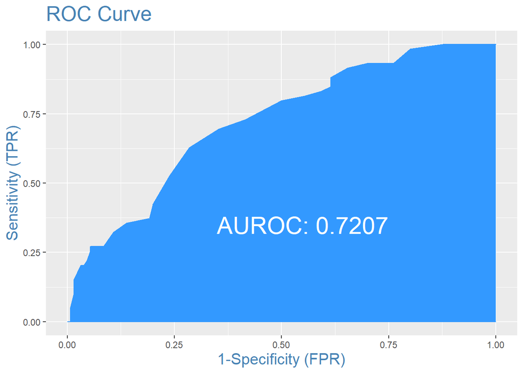

```r
plotROC(LOWBWT$LOW, predic_final)
```